```python
import pandas as pd
```

# TASK 1

```python
city = pd.read_csv(r"C:\Users\lavia\Downloads\city_day.csv\city_day.csv")
crop = pd.read_csv(r"C:\Users\lavia\Downloads\crop_production.csv\crop_production.csv")

print(city.shape)
print(crop.shape)
```

```
(29531, 16)
(246091, 7)
```

```python
print(city.head())
print()
print(crop.head())
```

```
        City        Date  PM2.5  PM10     NO    NO2    NOx  NH3     CO    SO2  \
0  Ahmedabad  2015-01-01    NaN   NaN   0.92  18.22  17.15  NaN   0.92  27.64
1  Ahmedabad  2015-01-02    NaN   NaN   0.97  15.69  16.46  NaN   0.97  24.55
2  Ahmedabad  2015-01-03    NaN   NaN  17.40  19.30  29.70  NaN  17.40  29.07
3  Ahmedabad  2015-01-04    NaN   NaN   1.70  18.48  17.97  NaN   1.70  18.59
4  Ahmedabad  2015-01-05    NaN   NaN  22.10  21.42  37.76  NaN  22.10  39.33

       O3  Benzene  Toluene  Xylene  AQI AQI_Bucket
0  133.36     0.00     0.02    0.00  NaN        NaN
1   34.06     3.68     5.50    3.77  NaN        NaN
2   30.70     6.80    16.40    2.25  NaN        NaN
3   36.08     4.43    10.14    1.00  NaN        NaN
4   39.31     7.01    18.89    2.78  NaN        NaN

                    State_Name District_Name  Crop_Year       Season  \
0  Andaman and Nicobar Islands      NICOBARS       2000  Kharif
1  Andaman and Nicobar Islands      NICOBARS       2000  Kharif
2  Andaman and Nicobar Islands      NICOBARS       2000  Kharif
3  Andaman and Nicobar Islands      NICOBARS       2000  Whole Year
4  Andaman and Nicobar Islands      NICOBARS       2000  Whole Year

                  Crop    Area  Production
0             Arecanut  1254.0      2000.0
1  Other Kharif pulses     2.0         1.0
2                 Rice   102.0       321.0
3               Banana   176.0       641.0
4            Cashewnut   720.0       165.0
```

```python
print(city.info())
```

```
<class 'pandas.core.frame.DataFrame'>
RangeIndex: 29531 entries, 0 to 29530
Data columns (total 16 columns):
 #   Column      Non-Null Count  Dtype
---  ------      --------------  -----
 0   City        29531 non-null  object
 1   Date        29531 non-null  object
 2   PM2.5       24933 non-null  float64
 3   PM10        18391 non-null  float64
 4   NO          25949 non-null  float64
 5   NO2         25946 non-null  float64
 6   NOx         25346 non-null  float64
 7   NH3         19203 non-null  float64
 8   CO          27472 non-null  float64
 9   SO2         25677 non-null  float64
 10  O3          25509 non-null  float64
 11  Benzene     23908 non-null  float64
 12  Toluene     21490 non-null  float64
 13  Xylene      11422 non-null  float64
 14  AQI         24850 non-null  float64
 15  AQI_Bucket  24850 non-null  object
dtypes: float64(13), object(3)
memory usage: 3.6+ MB
None
```

```python
print(crop.info())
```

```
<class 'pandas.core.frame.DataFrame'>
RangeIndex: 246091 entries, 0 to 246090
Data columns (total 7 columns):
 #   Column         Non-Null Count   Dtype
---  ------         --------------   -----
 0   State_Name     246091 non-null  object
 1   District_Name  246091 non-null  object
 2   Crop_Year      246091 non-null  int64
 3   Season         246091 non-null  object
 4   Crop           246091 non-null  object
 5   Area           246091 non-null  float64
 6   Production     242361 non-null  float64
dtypes: float64(2), int64(1), object(4)
memory usage: 13.1+ MB
None
```

```python
print(city.describe())
```

```
              PM2.5          PM10            NO           NO2           NOx  \
count  24933.000000  18391.000000  25949.000000  25946.000000  25346.000000
mean      67.450578    118.127103     17.574730     28.560659     32.309123
std       64.661449     90.605110     22.785846     24.474746     31.646011
min        0.040000      0.010000      0.020000      0.010000      0.000000
25%       28.820000     56.255000      5.630000     11.750000     12.820000
50%       48.570000     95.680000      9.890000     21.690000     23.520000
75%       80.590000    149.745000     19.950000     37.620000     40.127500
max      949.990000   1000.000000    390.680000    362.210000    467.630000

                NH3            CO           SO2            O3       Benzene  \
count  19203.000000  27472.000000  25677.000000  25509.000000  23908.000000
mean      23.483476      2.248598     14.531977     34.491430      3.280840
std       25.684275      6.962884     18.133775     21.694928     15.811136
min        0.010000      0.000000      0.010000      0.010000      0.000000
25%        8.580000      0.510000      5.670000     18.860000      0.120000
50%       15.850000      0.890000      9.160000     30.840000      1.070000
75%       30.020000      1.450000     15.220000     45.570000      3.080000
max      352.890000    175.810000    193.860000    257.730000    455.030000

            Toluene        Xylene           AQI
count  21490.000000  11422.000000  24850.000000
mean       8.700972      3.070128    166.463581
std       19.969164      6.323247    140.696585
min        0.000000      0.000000     13.000000
25%        0.600000      0.140000     81.000000
50%        2.970000      0.980000    118.000000
75%        9.150000      3.350000    208.000000
max      454.850000    170.370000   2049.000000
```

```python
print(crop.describe())
```

```
           Crop_Year          Area    Production
count  246091.000000  2.460910e+05  2.423610e+05
mean     2005.643018  1.200282e+04  5.825034e+05
std         4.952164  5.052340e+04  1.706581e+07
min      1997.000000  4.000000e-02  0.000000e+00
25%      2002.000000  8.000000e+01  8.800000e+01
50%      2006.000000  5.820000e+02  7.290000e+02
75%      2010.000000  4.392000e+03  7.023000e+03
max      2015.000000  8.580100e+06  1.250800e+09
```

```python
print(city.isnull().sum())
print()
print(crop.isnull().sum())
```

```
City              0
Date              0
PM2.5          4598
PM10          11140
NO             3582
NO2            3585
NOx            4185
NH3           10328
CO             2059
SO2            3854
O3             4022
Benzene        5623
Toluene        8041
Xylene        18109
AQI            4681
AQI_Bucket     4681
dtype: int64

State_Name          0
District_Name       0
Crop_Year           0
Season              0
Crop                0
Area                0
Production       3730
dtype: int64
```

```python
print(city.duplicated().sum())
print(crop.duplicated().sum())
```

```
0
0
```

### Air Quality Dataset

1. The dataset contains 29,531 records and 16 columns.
2. The Date column is stored as object datatype and must be converted to datetime before time-based analysis.
3. Several columns contain missing values.
4. Xylene has the highest missing values (18,109 missing records), indicating poor data availability.
5. AQI and AQI_Bucket are missing in 4,681 records.
6. No duplicate records were found.
7. AQI ranges from 13 to 2049, which is unusually high and suggests potential outliers.
8. The AQI mean is 166.46 while the median is 118, which indicates a right-skewed distribution influenced by extreme values.

### Crop Production Dataset

1. The dataset contains 246,091 records and 7 columns.
2. Production is the only column with missing values (3,730 records).
3. No duplicate records were detected.
4. Crop_Year ranges from 1997 to 2015.
5. Production values show large variation, ranging from 0 to 1.25 billion units.
6. Area and Production appear highly skewed because the maximum values are much larger than the median values.

# TASK 2

```python
print(city.isnull().sum())
print()
print(crop.isnull().sum())
```

```
City              0
Date              0
PM2.5          4598
PM10          11140
NO             3582
NO2            3585
NOx            4185
NH3           10328
CO             2059
SO2            3854
O3             4022
Benzene        5623
Toluene        8041
Xylene        18109
AQI            4681
AQI_Bucket     4681
dtype: int64

State_Name          0
District_Name       0
Crop_Year           0
Season              0
Crop                0
Area                0
Production       3730
dtype: int64
```

```python
city_missing = (city.isnull().sum() / len(city)) * 100
crop_missing = (crop.isnull().sum() / len(crop)) * 100

print("City Dataset Missing Percentage")
print(city_missing)
print("\nCrop Dataset Missing Percentage")
print(crop_missing)
```

```
City Dataset Missing Percentage
City           0.000000
Date           0.000000
PM2.5         15.570079
PM10          37.723071
NO            12.129626
NO2           12.139785
NOx           14.171549
NH3           34.973418
CO             6.972334
SO2           13.050692
O3            13.619586
Benzene       19.041008
Toluene       27.229014
Xylene        61.322001
AQI           15.851139
AQI_Bucket    15.851139
dtype: float64

Crop Dataset Missing Percentage
State_Name       0.000000
District_Name    0.000000
Crop_Year        0.000000
Season           0.000000
Crop             0.000000
Area             0.000000
Production       1.515699
dtype: float64
```

```python
missing_cols = city_missing[
    city_missing > 50
].index
print("Columns with more than 50% missing values:")
print(missing_cols)
```

```
Columns with more than 50% missing values:
Index(['Xylene'], dtype='object')
```

```python
city = city.drop(columns=missing_cols)
print(city.columns)
```

```
Index(['City', 'Date', 'PM2.5', 'PM10', 'NO', 'NO2', 'NOx', 'NH3', 'CO', 'SO2',
       'O3', 'Benzene', 'Toluene', 'AQI', 'AQI_Bucket'],
      dtype='object')
```

```python
num_cols = city.select_dtypes(include=['int64','float64']).columns
cat_cols = city.select_dtypes(include=['object']).columns
print("Numerical Columns - ")
print(num_cols)
print("\nCategorical Columns - ")
print(cat_cols)
```

```
Numerical Columns -
Index(['PM2.5', 'PM10', 'NO', 'NO2', 'NOx', 'NH3', 'CO', 'SO2', 'O3',
       'Benzene', 'Toluene', 'AQI'],
      dtype='object')

Categorical Columns -
Index(['City', 'Date', 'AQI_Bucket'], dtype='object')
```

```python
for col in num_cols:
    if city[col].isnull().sum() > 0:
        city[col] = city[col].fillna(
            city[col].median()
        )

for col in cat_cols:
    if city[col].isnull().sum() > 0:
        city[col] = city[col].fillna(
            city[col].mode()[0]

        )

print(city.isnull().sum())
```

```
City          0
Date          0
PM2.5         0
PM10          0
NO            0
NO2           0
NOx           0
NH3           0
CO            0
SO2           0
O3            0
Benzene       0
Toluene       0
AQI           0
AQI_Bucket    0
dtype: int64
```

```python
crop['Production'] = crop['Production'].fillna(
    crop['Production'].median()
)
print(crop.isnull().sum())
```

```
State_Name       0
District_Name    0
Crop_Year        0
Season           0
Crop             0
Area             0
Production       0
dtype: int64
```

```python
city.head()
```

|  | City | Date | PM2.5 | PM10 | NO | NO2 | NOx | NH3 | CO | SO2 | O3 | Benzene | Toluene | AQI | AQI_Bucket |
| --- | --- | --- | --- | --- | --- | --- | --- | --- | --- | --- | --- | --- | --- | --- | --- |
| 0 | Ahmedabad | 2015-01-01 | 48.57 | 95.68 | 0.92 | 18.22 | 17.15 | 15.85 | 0.92 | 27.64 | 133.36 | 0.00 | 0.02 | 118.0 | Moderate |
| 1 | Ahmedabad | 2015-01-02 | 48.57 | 95.68 | 0.97 | 15.69 | 16.46 | 15.85 | 0.97 | 24.55 | 34.06 | 3.68 | 5.50 | 118.0 | Moderate |
| 2 | Ahmedabad | 2015-01-03 | 48.57 | 95.68 | 17.40 | 19.30 | 29.70 | 15.85 | 17.40 | 29.07 | 30.70 | 6.80 | 16.40 | 118.0 | Moderate |
| 3 | Ahmedabad | 2015-01-04 | 48.57 | 95.68 | 1.70 | 18.48 | 17.97 | 15.85 | 1.70 | 18.59 | 36.08 | 4.43 | 10.14 | 118.0 | Moderate |
| 4 | Ahmedabad | 2015-01-05 | 48.57 | 95.68 | 22.10 | 21.42 | 37.76 | 15.85 | 22.10 | 39.33 | 39.31 | 7.01 | 18.89 | 118.0 | Moderate |

```python
crop.head()
```

|  | State_Name | District_Name | Crop_Year | Season | Crop | Area | Production |
| --- | --- | --- | --- | --- | --- | --- | --- |
| 0 | Andaman and Nicobar Islands | NICOBARS | 2000 | Kharif | Arecanut | 1254.0 | 2000.0 |
| 1 | Andaman and Nicobar Islands | NICOBARS | 2000 | Kharif | Other Kharif pulses | 2.0 | 1.0 |
| 2 | Andaman and Nicobar Islands | NICOBARS | 2000 | Kharif | Rice | 102.0 | 321.0 |
| 3 | Andaman and Nicobar Islands | NICOBARS | 2000 | Whole Year | Banana | 176.0 | 641.0 |
| 4 | Andaman and Nicobar Islands | NICOBARS | 2000 | Whole Year | Cashewnut | 720.0 | 165.0 |

### Missing Value Strategy

Approach I used to handle misisng values:

Step 1: Calculated the percentage of missing values for every column

Step 2: Columns with more than 50% missing values were dropped because this could introduce significant bias and reduce reliability.

Step 3: For the remaining numerical columns, missing values were replaced using the median. Not mean because pollution and agricultural measurements contain extreme values and skewed distributions.

Step 4: For categorical columns, missing values were replaced using the mode .

# TASK 3

```python
print(city['City'].nunique())
print()
print(city['City'].unique())
```

```
26

['Ahmedabad' 'Aizawl' 'Amaravati' 'Amritsar' 'Bengaluru' 'Bhopal'
 'Brajrajnagar' 'Chandigarh' 'Chennai' 'Coimbatore' 'Delhi' 'Ernakulam'
 'Gurugram' 'Guwahati' 'Hyderabad' 'Jaipur' 'Jorapokhar' 'Kochi' 'Kolkata'
 'Lucknow' 'Mumbai' 'Patna' 'Shillong' 'Talcher' 'Thiruvananthapuram'
 'Visakhapatnam']
```

```python
city_state_map = {
    'Ahmedabad': 'Gujarat',
    'Aizawl': 'Mizoram',
    'Amaravati': 'Andhra Pradesh',
    'Amritsar': 'Punjab',
    'Bengaluru': 'Karnataka',
    'Bhopal': 'Madhya Pradesh',
    'Brajrajnagar': 'Odisha',
    'Chandigarh': 'Chandigarh',
    'Chennai': 'Tamil Nadu',
    'Coimbatore': 'Tamil Nadu',
    'Delhi': 'Delhi',
    'Ernakulam': 'Kerala',
    'Gurugram': 'Haryana',
    'Guwahati': 'Assam',
    'Hyderabad': 'Telangana',
    'Jaipur': 'Rajasthan',
    'Jorapokhar': 'Jharkhand',
    'Kochi': 'Kerala',
    'Kolkata': 'West Bengal',
    'Lucknow': 'Uttar Pradesh',
    'Mumbai': 'Maharashtra',
    'Patna': 'Bihar',
    'Shillong': 'Meghalaya',
    'Talcher': 'Odisha',
    'Thiruvananthapuram': 'Kerala',
    'Visakhapatnam': 'Andhra Pradesh'
}

city['State'] = city['City'].map(city_state_map)

print(city[['City','State']].head())
```

```
        City    State
0  Ahmedabad  Gujarat
1  Ahmedabad  Gujarat
2  Ahmedabad  Gujarat
3  Ahmedabad  Gujarat
4  Ahmedabad  Gujarat
```

```python
print("AQI States:")
print(sorted(city['State'].unique()))
print("\nCrop States:")
print(sorted(crop['State_Name'].unique()))
```

[output not shown]

```python
city['State'] = city['State'].str.strip()
crop['State_Name'] = crop['State_Name'].str.strip()
```

```python
city['State'] = city['State'].str.title()
crop['State_Name'] = crop['State_Name'].str.title()
```

```python
city_duplicates = city.duplicated().sum()
crop_duplicates = crop.duplicated().sum()

print("City duplicates:", city_duplicates)
print("Crop duplicates:", crop_duplicates)
```

```
City duplicates: 0
Crop duplicates: 0
```

```python
city_before = len(city)
crop_before = len(crop)
print("City records before:", city_before)
print("Crop records before:", crop_before)
```

```
City records before: 29531
Crop records before: 246091
```

```python
print(city[['City','State']].sample(10))
```

```
                     City           State
28695       Visakhapatnam  Andhra Pradesh
28059  Thiruvananthapuram          Kerala
29075       Visakhapatnam  Andhra Pradesh
12429            Gurugram         Haryana
18685          Jorapokhar       Jharkhand
28171       Visakhapatnam  Andhra Pradesh
5958            Bengaluru       Karnataka
22220              Mumbai     Maharashtra
28136       Visakhapatnam  Andhra Pradesh
23184              Mumbai     Maharashtra
```

### State Name Standardization and Duplicate Removal

The AQI dataset originally contained only city names, while the crop dataset contained state names. State column was created in the AQI dataset using a city-to-state mapping.

The following were handled:

1. Extra leading and trailing spaces in state names.
2. Inconsistent capitalization of state names.
3. Legacy state names such as Orissa and Uttaranchal (if present).
4. Duplicate records.

### Observations

- A State column was created in the AQI dataset using a city-to-state mapping for all 26 cities.
- State names in both datasets were standardized by removing extra spaces and applying consistent capitalization.
- State names were checked for naming inconsistencies such as old or alternate state names and corrected where necessary.
- Duplicate records were checked in both datasets and no duplicate entries were found.

# TASK 4

```python
import matplotlib.pyplot as plt
import seaborn as sns
```

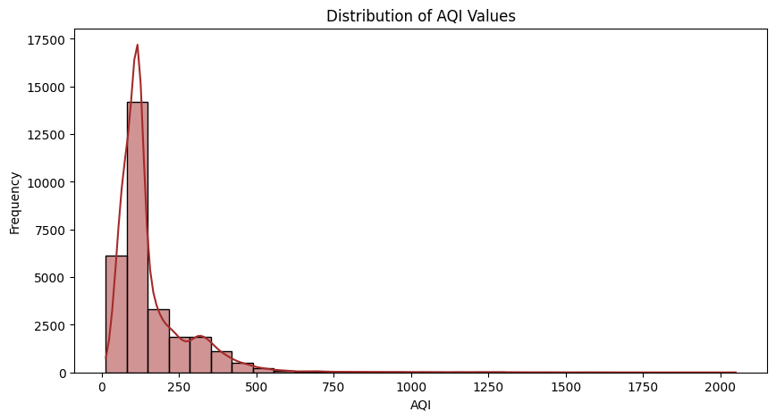

```python
#Are most cities moderately polluted or are only a few cities heavily polluted?

plt.figure(figsize=(10,5))
sns.histplot(city['AQI'], bins=30, kde=True, color='brown')
plt.title("Distribution of AQI Values")
plt.xlabel("AQI")
plt.ylabel("Frequency")
plt.show()
```

A histogram because it shows how AQI values are distributed and helps identify the range in which most observations are concentrated.

### Observation

- Most AQI observations are concentrated between 50 and 250, indicating that the majority of cities experience moderate to poor air quality levels.
- The distribution is positively skewed (right-skewed), with a long tail extending toward very high AQI values.
- Very few observations have AQI values above 500, suggesting that extreme pollution events are relatively uncommon.

### Conclusion

The histogram shows that air pollution is not evenly distributed across observations. Most AQI readings fall within moderate ranges, while a smaller number of extremely high AQI values create a long right tail in the distribution.

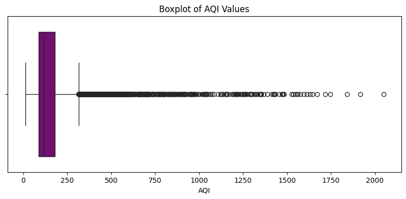

```python
# Is the average AQI being unfairly increased by a few extreme cities?
plt.figure(figsize=(10,4))
sns.boxplot(x=city['AQI'], color='purple')
plt.title("Boxplot of AQI Values")
plt.xlabel("AQI")
plt.show()
```

A boxplot was chosen because it clearly identifies outliers and helps determine whether extreme AQI values may influence summary statistics such as the mean.

### Observation

- The boxplot reveals a large number of outliers beyond the upper whisker.
- Several AQI values exceed 1000, with the highest values crossing 2000.
- The spread of the data is substantial, indicating considerable variation in air quality across cities and time periods.
- The mean AQI (158.78) is significantly higher than the median AQI (118), confirming the influence of extreme values.

### Conclusion

The boxplot confirms the presence of numerous extreme AQI values. These outliers increase the average AQI and make the mean less representative of typical air quality conditions. The median provides a more reliable measure of the central tendency of AQI in this dataset.

```python
print("Mean AQI:", city['AQI'].mean())
print("Median AQI:", city['AQI'].median())
```

```
Mean AQI: 158.78155158985473
Median AQI: 118.0
```

# TASK 5

```python
Q1 = city['AQI'].quantile(0.25)

Q3 = city['AQI'].quantile(0.75)

IQR = Q3 - Q1

print("Q1:", Q1)
print("Q3:", Q3)
print("IQR:", IQR)
```

```
Q1: 88.0
Q3: 179.0
IQR: 91.0
```

```python
lower_bound = Q1 - (1.5 * IQR)
upper_bound = Q3 + (1.5 * IQR)

print("Lower Bound:", lower_bound)
print("Upper Bound:", upper_bound)
```

```
Lower Bound: -48.5
Upper Bound: 315.5
```

```python
outliers = city[
    (city['AQI'] < lower_bound) |
    (city['AQI'] > upper_bound)
]
print("Number of Outliers:", len(outliers))
```

```
Number of Outliers: 3192
```

```python
outlier_percentage = (
    len(outliers) / len(city)
) * 100

print("Outlier Percentage:", round(outlier_percentage,2), "%")
```

```
Outlier Percentage: 10.81 %
```

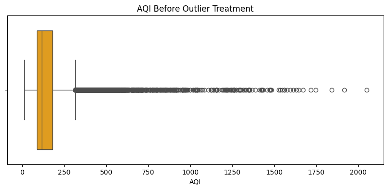

```python
plt.figure(figsize=(10,4))
sns.boxplot(
    x=city['AQI'],
    color='orange'
)
plt.title("AQI Before Outlier Treatment")
plt.show()
```

### Observation

- The IQR method identified 3,192 outlier observations in the AQI dataset.
- These outliers account for approximately 10.81% of all records.
- Most outliers occur on the upper side of the distribution, indicating unusually high pollution levels.
- The boxplot shows a large number of extreme AQI values extending far beyond the upper whisker.
- The presence of these extreme observations explains the strong right-skew observed in Task 4.

```python
city['AQI_Clean'] = city['AQI'].clip(
    lower=lower_bound,
    upper=upper_bound
)
```

We can't delete outlier rows as

- We will lose genuine data.
- AQI values above 500 are real pollution events.

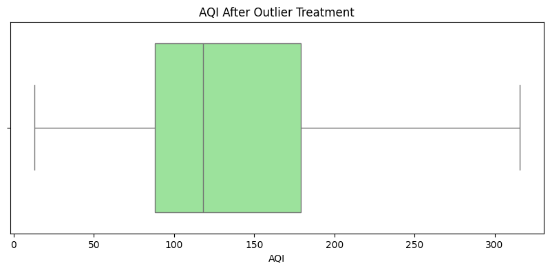

```python
plt.figure(figsize=(10,4))
sns.boxplot(
    x=city['AQI_Clean'],
    color='lightgreen'

)
plt.title("AQI After Outlier Treatment")
plt.xlabel("AQI")
plt.show()
```

### Observation

- The boxplot after treatment shows a much more compact AQI distribution.
- Extreme AQI values beyond the upper whisker are no longer visible.
- The spread of the data has reduced considerably compared to the original distribution.
- All observations were retained, but extreme values were capped at the IQR limits.
- Recalculation confirmed that the percentage of outliers decreased from 10.81% to 0%.

```python
print(city[['AQI','AQI_Clean']].describe())
```

```
                AQI     AQI_Clean
count  29531.000000  29531.000000
mean     158.781552    145.047205
std      130.272413     82.612919
min       13.000000     13.000000
25%       88.000000     88.000000
50%      118.000000    118.000000
75%      179.000000    179.000000
max     2049.000000    315.500000
```

```python
new_outliers = city[
    (city['AQI_Clean'] < lower_bound) |
    (city['AQI_Clean'] > upper_bound)
]

print("Remaining Outliers:", len(new_outliers))
```

```
Remaining Outliers: 0
```

The number of outliers reduced from 3,192 (10.81%) before treatment to 0 (0%) after treatment, confirming the effectiveness of the IQR-based capping approach.

# TASK 6

Is India's air getting better or worse over time?

Why use a Line Chart?

- Years are ordered chronologically.
- To observe trends over time.
- Line charts are the best choice for time-series analysis.

```python
#coverting date to datetime
print(city['Date'].dtype)
```

```
object
```

```python
city['Date'] = pd.to_datetime(city['Date'])
print(city['Date'].dtype)
```

```
datetime64[ns]
```

```python
#extracting year from date
city['Year'] = city['Date'].dt.year
print(city[['Date','Year']].head())
```

```
        Date  Year
0 2015-01-01  2015
1 2015-01-02  2015
2 2015-01-03  2015
3 2015-01-04  2015
4 2015-01-05  2015
```

```python
#Average AQI per Year
yearly_aqi = city.groupby('Year')['AQI_Clean'].mean()
print(yearly_aqi)
```

```
Year
2015    165.871474
2016    162.840426
2017    149.960013
2018    152.574641
2019    140.593406
2020    110.867951
Name: AQI_Clean, dtype: float64
```

```python
most_polluted_year = yearly_aqi.idxmax()
least_polluted_year = yearly_aqi.idxmin()

print("Most Polluted Year:", most_polluted_year)
print("AQI:", yearly_aqi.max())

print("\nLeast Polluted Year:", least_polluted_year)
print("AQI:", yearly_aqi.min())
```

```
Most Polluted Year: 2015
AQI: 165.87147447340234

Least Polluted Year: 2020
AQI: 110.86795092552734
```

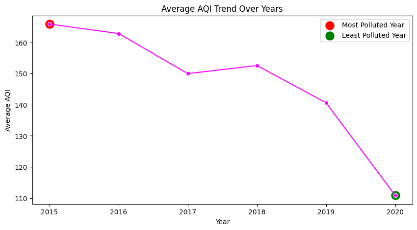

```python
plt.figure(figsize=(10,5))

sns.lineplot(
    x=yearly_aqi.index,
    y=yearly_aqi.values,
    marker='o',
    color='magenta'
)

plt.scatter(
    most_polluted_year,
    yearly_aqi.max(),
    s=150,
    color='red',
    label='Most Polluted Year'
)

plt.scatter(
    least_polluted_year,
    yearly_aqi.min(),
    s=150,
    color='green',
    label='Least Polluted Year'
)

plt.title("Average AQI Trend Over Years")
plt.xlabel("Year")
plt.ylabel("Average AQI")
plt.legend()
plt.show()
```

### Observation

- The average AQI shows an overall decreasing trend from 2015 to 2020.
- The highest average AQI was recorded in 2015 (165.87), indicating poorer air quality during that year.
- AQI decreased slightly from 2015 to 2017, followed by a small increase in 2018.
- After 2018, the AQI declined significantly, reaching 140.59 in 2019.
- The lowest average AQI was observed in 2020 (110.87).
- The line graph indicates a substantial improvement in air quality over the study period.

### Conclusion

Air quality have improved over time. The average AQI decreased from 165.87 in 2015, the most polluted year in the dataset, to 110.87 in 2020, the least polluted year. Although there was a small increase in pollution during 2018, the overall trend shows a steady decline in AQI levels. This suggests that air pollution became less severe. While the data alone cannot prove which specific policy caused the improvement, the reduction in average AQI after 2018 is consistent with the possibility that pollution control efforts may have contributed to better air quality.

```python
aqi_improvement = (
    (yearly_aqi[2015] - yearly_aqi[2020])
    / yearly_aqi[2015]
) * 100

print(round(aqi_improvement, 2))
```

```
33.16
```

The average AQI decreased by approximately 33.16% between 2015 and 2020, indicating a improvement in air quality.

# TASK 7

```python
#Extracting Month
city['Month'] = city['Date'].dt.month
city['Month'].tail()
```

```
29526    6
29527    6
29528    6
29529    6
29530    7
Name: Month, dtype: int32
```

```python
# Average AQI by Month
monthly_aqi = city.groupby('Month')['AQI_Clean'].mean()
print(monthly_aqi)
```

```
Month
1     186.443915
2     170.707163
3     145.196435
4     131.728164
5     129.015243
6     115.312522
7     106.360883
8     107.939770
9     110.539577
10    158.246575
11    190.909814
12    188.517146
Name: AQI_Clean, dtype: float64
```

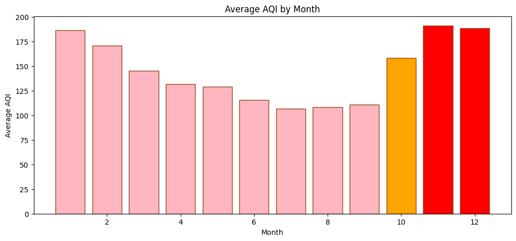

```python
colors = [
    'lightpink','lightpink','lightpink','lightpink',
    'lightpink','lightpink','lightpink','lightpink',
    'lightpink','orange','red','red'
]
plt.figure(figsize=(12,5))
plt.bar(
    monthly_aqi.index,
    monthly_aqi.values,
    color=colors,
    edgecolor='saddlebrown'
)
plt.title("Average AQI by Month")
plt.xlabel("Month")
plt.ylabel("Average AQI")
plt.show()
```

### Observations

- Air quality gradually improves from January to July, reaching its lowest level in July (106.36).
- AQI remains relatively low during July, August, and September.
- A sharp increase in AQI is observed from October onwards.
- November records the highest average AQI (190.91), followed closely by December (188.52).
- The October–December period consistently shows significantly higher AQI levels than most other months.
- This seasonal pattern suggests that pollution levels are substantially worse during the harvest season.

### Conclusion

The analysis supports the NGO's claim that air quality is generally worse during the October–December harvest season. Average AQI rises sharply from 110.54 in September to 158.25 in October and peaks at 190.91 in November. While this analysis cannot directly prove that crop residue burning is the sole cause, the timing of the increase is consistent with the harvest period and indicates a strong seasonal deterioration in air quality during these months.

# TASK 8

```python
print(city['Year'].min(), city['Year'].max())
print(crop['Crop_Year'].min(), crop['Crop_Year'].max())
```

```
2015 2020
1997 2015
```

### Transformation Required Before Merge

The AQI dataset contains records from 2015–2020, while the crop dataset contains records from 1997–2015. Therefore, the two datasets overlap only in the year 2015.

```python
#State-wise AQI Dataset
aqi_state = city.groupby(
    'State'
)['AQI_Clean'].mean().reset_index()
aqi_state.head(10)
```

|  | State | AQI_Clean |
| --- | --- | --- |
| 0 | Andhra Pradesh | 109.675715 |
| 1 | Assam | 135.423307 |
| 2 | Bihar | 195.606028 |
| 3 | Chandigarh | 96.766447 |
| 4 | Delhi | 232.569189 |
| 5 | Gujarat | 219.665754 |
| 6 | Haryana | 195.754318 |
| 7 | Jharkhand | 141.818648 |
| 8 | Karnataka | 95.444251 |
| 9 | Kerala | 82.901114 |

```python
#State-wise Crop Dataset
crop_state = crop.groupby(
    'State_Name'
)['Production'].sum().reset_index()
crop_state.head(10)
```

|  | State_Name | Production |
| --- | --- | --- |
| 0 | Andaman And Nicobar Islands | 7.182247e+08 |
| 1 | Andhra Pradesh | 1.732464e+10 |
| 2 | Arunachal Pradesh | 6.824642e+06 |
| 3 | Assam | 2.111756e+09 |
| 4 | Bihar | 3.664916e+08 |
| 5 | Chandigarh | 6.468550e+04 |
| 6 | Chhattisgarh | 1.012005e+08 |
| 7 | Dadra And Nagar Haveli | 1.847871e+06 |
| 8 | Goa | 5.057565e+08 |
| 9 | Gujarat | 5.243431e+08 |

```python
crop_state.rename(
    columns={'State_Name':'State'},
    inplace=True
)
```

```python
print(aqi_state.shape)

print(crop_state.shape)
```

```
(21, 2)
(33, 2)
```

```python
merged_df = pd.merge(
    aqi_state,
    crop_state,
    on='State',
    how='inner'
)
print(merged_df.shape)
merged_df.head(10)
```

```
(20, 3)
```

|  | State | AQI_Clean | Production |
| --- | --- | --- | --- |
| 0 | Andhra Pradesh | 109.675715 | 1.732464e+10 |
| 1 | Assam | 135.423307 | 2.111756e+09 |
| 2 | Bihar | 195.606028 | 3.664916e+08 |
| 3 | Chandigarh | 96.766447 | 6.468550e+04 |
| 4 | Gujarat | 219.665754 | 5.243431e+08 |
| 5 | Haryana | 195.754318 | 3.822471e+08 |
| 6 | Jharkhand | 141.818648 | 1.077774e+07 |
| 7 | Karnataka | 95.444251 | 8.634612e+08 |
| 8 | Kerala | 82.901114 | 9.788023e+10 |
| 9 | Madhya Pradesh | 132.262976 | 4.490879e+08 |

```python
#Correlation Analysis
corr_matrix = merged_df.corr(
    numeric_only=True
)
print(corr_matrix)
```

```
            AQI_Clean  Production
AQI_Clean    1.000000   -0.252456
Production  -0.252456    1.000000
```

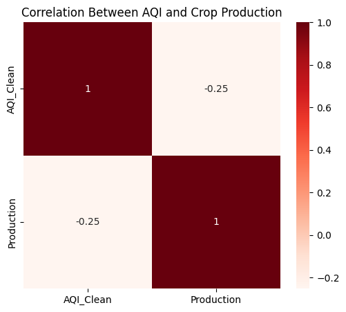

```python
import seaborn as sns
import matplotlib.pyplot as plt

plt.figure(figsize=(6,5))

sns.heatmap(
    corr_matrix,
    annot=True,
    cmap='Reds'
)
plt.title(
    'Correlation Between AQI and Crop Production'
)
plt.show()
```

### Observations

- The AQI and crop datasets were successfully transformed to the state level and merged using the State column as the common key.
- The merged dataset contained 20 states with information on both average AQI and crop production.
- The correlation matrix shows a negative correlation (-0.252) between AQI and crop production.
- This suggests that states with higher pollution levels generally tend to have lower crop production.
- However, the correlation is weak, indicating that air pollution alone does not fully explain differences in agricultural output across states.

### Conclusion

After transforming both datasets to the state level and merging them using the State column, a weak negative relationship (-0.252) was observed between AQI and crop production. This suggests that higher pollution may be associated with lower agricultural output, but the relationship is not strong enough to conclude that pollution is the primary cause. Additional factors such as rainfall, irrigation, soil quality, crop selection, and economic conditions likely influence agricultural production and are not captured in the available datasets.

# TASK 9

### Briefing for the State Environment Minister

**1. Air quality has improved over time**

- Average AQI decreased from **165.87 in 2015** to **110.87 in 2020**.
- This represents an improvement of approximately **33%** over the study period.
- The overall trend suggests that pollution levels have generally declined.

**2. Pollution is highest during the harvest season**

- AQI increases sharply during **October–December**.
- **November recorded the highest average AQI (190.91)** among all months.
- This seasonal pattern is consistent with concerns regarding crop residue burning and other harvest-related activities.

**3. Higher pollution is associated with lower crop production**

- A weak negative relationship (**correlation = -0.252**) was observed between AQI and crop production.
- States with higher pollution levels generally tended to have lower agricultural output.
- However, the relationship is not strong enough to conclude that pollution is the primary cause.

### Recommendation

- Strengthen pollution-control measures during the **October–December harvest season**.

### Limitation

- Important factors such as rainfall, irrigation, soil quality, crop type, and farming practices were not available in the dataset and may also influence crop production.